# Project: Wrangling and Analyze Data

## Table of Contents (TOC)

1. Data Gathering
2. Assessing Data
3. Identification and Listing Issues

   3.1 Quality Issues

   3.2 Tidinness Issues
4. Data Cleaning

   4.1 Issue 1

   4.2 Issue 2

   4.3 Issue 3

   4.4 Issue 4

   4.5 Issue 5

   4.6 Issue 6

   4.7 Issue 7

   4.8 Issue 8

   4.9 Issue 9

   4.10 Issue 10
5. Storing Data
6. Insights and Visualization

   6.1 Insights

   6.2 Visualizations
7. Reference

## Data Gathering

In the cell below, gather **all** three pieces of data for this project and load them in the notebook. **Note:** the methods required to gather each data are different.

1. Directly download the WeRateDogs Twitter archive data (twitter_archive_enhanced.csv)

```python
# Importing appropriate modules/packages

import pandas as pd
import numpy as np
import tweepy
import json
import requests
import seaborn as sb
import matplotlib.pyplot as plt
```

```python
df = pd.read_csv(r"C:\Users\User\Documents\Udacity\Project II\twitter-archive-enhanced.csv")
# Displaying the first 5 rows
df.sample(3)
```

|  | tweet_id | in_reply_to_status_id | in_reply_to_user_id | timestamp | source | text | retweeted_status_id | retweeted_status_user_id | retweeted_status_timestamp | expanded_urls | rating_numerator | rating_denominator | name | doggo | floofer | pupper | puppo |
| --- | --- | --- | --- | --- | --- | --- | --- | --- | --- | --- | --- | --- | --- | --- | --- | --- | --- |
| 365 | 829011960981237760 | NaN | NaN | 2017-02-07 17:00:28 +0000 | <a href="http://twitter.com/download/iphone" r... | This is Dexter. He was reunited with his mom y... | NaN | NaN | NaN | https://twitter.com/dog_rates/status/829011960... | 13 | 10 | Dexter | None | None | None | None |
| 615 | 796563435802726400 | NaN | NaN | 2016-11-10 04:01:37 +0000 | <a href="http://twitter.com/download/iphone" r... | RT @dog_rates: I want to finally rate this ico... | 7.809316e+17 | 4.196984e+09 | 2016-09-28 00:46:20 +0000 | https://twitter.com/dog_rates/status/780931614... | 13 | 10 | None | None | None | None | puppo |
| 873 | 761334018830917632 | NaN | NaN | 2016-08-04 22:52:29 +0000 | <a href="http://twitter.com/download/iphone" r... | This is Bruce. I really want to hear the joke ... | NaN | NaN | NaN | https://twitter.com/dog_rates/status/761334018... | 10 | 10 | Bruce | None | None | None | None |

1. Use the Requests library to download the tweet image prediction (image_predictions.tsv)

```python
url = 'https://d17h27t6h515a5.cloudfront.net/topher/2017/August/599fd2ad_image-predictions/image-predictions.tsv'
```

```python
r = requests.get(url, auth=('user', 'pass'))
r.status_code
```

```
200
```

```python
r.headers['content-type']
```

```
'text/tab-separated-values; charset=utf-8'
```

```python
r.encoding
```

```
'utf-8'
```

```python
# Using Python's with open method in opening the file
#  the "wb" mode opens the file in binary format for writing
with open('image_predictions.tsv', 'wb') as data_file:
    data_file.write(r.content)
```

```python
# Reading the image predictions file and saving the data as a variable
df_image_predictions = pd.read_csv('image_predictions.tsv', sep='\t')

# Viewing part of the data, sample of 10 random rows
df_image_predictions.sample(10)
```

|  | tweet_id | jpg_url | img_num | p1 | p1_conf | p1_dog | p2 | p2_conf | p2_dog | p3 | p3_conf | p3_dog |
| --- | --- | --- | --- | --- | --- | --- | --- | --- | --- | --- | --- | --- |
| 164 | 668975677807423489 | https://pbs.twimg.com/media/CUit1O1WoAEBHjj.jpg | 1 | basset | 0.605437 | True | Welsh_springer_spaniel | 0.184783 | True | Saint_Bernard | 0.116299 | True |
| 332 | 672139350159835138 | https://pbs.twimg.com/media/CVPrLE2WwAELCxD.jpg | 1 | Rottweiler | 0.290992 | True | American_black_bear | 0.238120 | False | chimpanzee | 0.115541 | False |
| 1072 | 716791146589110272 | https://pbs.twimg.com/media/CfKNvU8WsAAvI9Z.jpg | 1 | Pomeranian | 0.468751 | True | seat_belt | 0.154652 | False | golden_retriever | 0.125017 | True |
| 873 | 697995514407682048 | https://pbs.twimg.com/media/Ca_HN8UWEAEB-ga.jpg | 1 | Staffordshire_bullterrier | 0.280222 | True | Boston_bull | 0.161478 | True | American_Staffordshire_terrier | 0.126884 | True |
| 157 | 668852170888998912 | https://pbs.twimg.com/media/CUg9gBvWoAAmx-2.jpg | 1 | golden_retriever | 0.903529 | True | Tibetan_mastiff | 0.041497 | True | kuvasz | 0.022500 | True |
| 1871 | 844973813909606400 | https://pbs.twimg.com/media/C7nzMwTV4AARz4t.jpg | 1 | Labrador_retriever | 0.742421 | True | golden_retriever | 0.195218 | True | Chihuahua | 0.017320 | True |
| 217 | 670069087419133954 | https://pbs.twimg.com/media/CUyQRzHWoAAhF1D.jpg | 1 | boathouse | 0.313829 | False | birdhouse | 0.138331 | False | ashcan | 0.045673 | False |
| 2047 | 886736880519319552 | https://pbs.twimg.com/media/DE5Se8FXcAAJFx4.jpg | 1 | kuvasz | 0.309706 | True | Great_Pyrenees | 0.186136 | True | Dandie_Dinmont | 0.086346 | True |
| 1455 | 777621514455814149 | https://pbs.twimg.com/media/Csqqoo5WEAAMTVW.jpg | 1 | chow | 0.999823 | True | Norwich_terrier | 0.000056 | True | Pomeranian | 0.000028 | True |
| 619 | 680440374763077632 | https://pbs.twimg.com/ext_tw_video_thumb/68044... | 1 | space_heater | 0.920367 | False | radiator | 0.049933 | False | electric_fan | 0.006719 | False |

1. Use the Tweepy library to query additional data via the Twitter API (tweet_json.txt)

```python
# Using the available twitter information we have
# First, importing tweepy
import tweepy

consumer_key = 'KEY'
consumer_secret = 'KEY'
access_token = 'KEY'
access_secret = 'KEY'

auth = tweepy.OAuthHandler(consumer_key, consumer_secret)
auth.set_access_token(access_token, access_secret)

api = tweepy.API(auth, wait_on_rate_limit = True)
```

```python
for tweet_id in df['tweet_id']:
    try:
        tweet = api.get_status(tweet_id, tweet_mode = 'extended')
        with open('tweet_json.txt', 'a+') as file:
            json.dump(tweet._json, file)
            file.write('\n')
        print ("for id ", tweet_id, 'Success')
    except:
        print ("for id ", tweet_id, 'Failure')
```

[output not shown]

[output cut: 846 more lines]

[output not shown]

```
Rate limit reached. Sleeping for: 209
```

[output not shown]

[output cut: 845 more lines]

[output not shown]

```
Rate limit reached. Sleeping for: 244
```

[output not shown]

[output cut: 500 more lines]

[output not shown]

```python
# Here, now saving the data in tweet_json
tweet_json = []
with open('tweet_json.txt', 'r') as file:
    content = file.readlines()
    for i in range(len(content)):
        tweet = []
        # now appending contents as found in the dataset, i.e., id, retweet_count, favorite_count and is_quote_status
        tweet.append(json.loads(content[i])['id'])
        tweet.append(json.loads(content[i])['retweet_count'])
        tweet.append(json.loads(content[i])['favorite_count'])
        tweet.append(json.loads(content[i])['is_quote_status'])

        # Merging tweet_json with tweet dataframe
        tweet_json.append(tweet)
```

```python
# Saving in dataframe, which will be used in subsequent analysis
# For consistency, "id" is changed to "tweet_id", which is also same in twitter_acrhive data
dataframe_column_names = ['tweet_id', 'retweet_count', 'favorite_count', 'is_quote_status']
tweet_json = pd.DataFrame(tweet_json, columns = dataframe_column_names)
```

## Assessing Data

In this section, detect and document at least **eight (8) quality issues and two (2) tidiness issue**. You must use **both** visual assessment programmatic assessement to assess the data.

**Note:** pay attention to the following key points when you access the data.

- You only want original ratings (no retweets) that have images. Though there are 5000+ tweets in the dataset, not all are dog ratings and some are retweets.
- Assessing and cleaning the entire dataset completely would require a lot of time, and is not necessary to practice and demonstrate your skills in data wrangling. Therefore, the requirements of this project are only to assess and clean at least 8 quality issues and at least 2 tidiness issues in this dataset.
- The fact that the rating numerators are greater than the denominators does not need to be cleaned. This [unique rating system](http://knowyourmeme.com/memes/theyre-good-dogs-brent) is a big part of the popularity of WeRateDogs.
- You do not need to gather the tweets beyond August 1st, 2017. You can, but note that you won't be able to gather the image predictions for these tweets since you don't have access to the algorithm used.

```python
# Using describe to get an overview of the dataframe and its variable's descriptrive statistics
df.describe()
```

|  | tweet_id | in_reply_to_status_id | in_reply_to_user_id | retweeted_status_id | retweeted_status_user_id | rating_numerator | rating_denominator |
| --- | --- | --- | --- | --- | --- | --- | --- |
| count | 2.356000e+03 | 7.800000e+01 | 7.800000e+01 | 1.810000e+02 | 1.810000e+02 | 2356.000000 | 2356.000000 |
| mean | 7.427716e+17 | 7.455079e+17 | 2.014171e+16 | 7.720400e+17 | 1.241698e+16 | 13.126486 | 10.455433 |
| std | 6.856705e+16 | 7.582492e+16 | 1.252797e+17 | 6.236928e+16 | 9.599254e+16 | 45.876648 | 6.745237 |
| min | 6.660209e+17 | 6.658147e+17 | 1.185634e+07 | 6.661041e+17 | 7.832140e+05 | 0.000000 | 0.000000 |
| 25% | 6.783989e+17 | 6.757419e+17 | 3.086374e+08 | 7.186315e+17 | 4.196984e+09 | 10.000000 | 10.000000 |
| 50% | 7.196279e+17 | 7.038708e+17 | 4.196984e+09 | 7.804657e+17 | 4.196984e+09 | 11.000000 | 10.000000 |
| 75% | 7.993373e+17 | 8.257804e+17 | 4.196984e+09 | 8.203146e+17 | 4.196984e+09 | 12.000000 | 10.000000 |
| max | 8.924206e+17 | 8.862664e+17 | 8.405479e+17 | 8.874740e+17 | 7.874618e+17 | 1776.000000 | 170.000000 |

```python
df.info()
```

```
<class 'pandas.core.frame.DataFrame'>
RangeIndex: 2356 entries, 0 to 2355
Data columns (total 17 columns):
 #   Column                      Non-Null Count  Dtype
---  ------                      --------------  -----
 0   tweet_id                    2356 non-null   int64
 1   in_reply_to_status_id       78 non-null     float64
 2   in_reply_to_user_id         78 non-null     float64
 3   timestamp                   2356 non-null   object
 4   source                      2356 non-null   object
 5   text                        2356 non-null   object
 6   retweeted_status_id         181 non-null    float64
 7   retweeted_status_user_id    181 non-null    float64
 8   retweeted_status_timestamp  181 non-null    object
 9   expanded_urls               2297 non-null   object
 10  rating_numerator            2356 non-null   int64
 11  rating_denominator          2356 non-null   int64
 12  name                        2356 non-null   object
 13  doggo                       2356 non-null   object
 14  floofer                     2356 non-null   object
 15  pupper                      2356 non-null   object
 16  puppo                       2356 non-null   object
dtypes: float64(4), int64(3), object(10)
memory usage: 313.0+ KB
```

```python
# checking for posible duplicates
df.duplicated().sum()
```

```
0
```

## Checking the df_image_predictions dataframe

```python
df_image_predictions.info()
```

```
<class 'pandas.core.frame.DataFrame'>
RangeIndex: 2075 entries, 0 to 2074
Data columns (total 12 columns):
 #   Column    Non-Null Count  Dtype
---  ------    --------------  -----
 0   tweet_id  2075 non-null   int64
 1   jpg_url   2075 non-null   object
 2   img_num   2075 non-null   int64
 3   p1        2075 non-null   object
 4   p1_conf   2075 non-null   float64
 5   p1_dog    2075 non-null   bool
 6   p2        2075 non-null   object
 7   p2_conf   2075 non-null   float64
 8   p2_dog    2075 non-null   bool
 9   p3        2075 non-null   object
 10  p3_conf   2075 non-null   float64
 11  p3_dog    2075 non-null   bool
dtypes: bool(3), float64(3), int64(2), object(4)
memory usage: 152.1+ KB
```

```python
# checking for posible duplicates
df_image_predictions.duplicated().sum()
```

```
0
```

```python
# Using describe to examine descriptive statistics for the dataframe
df_image_predictions.describe()
```

|  | tweet_id | img_num | p1_conf | p2_conf | p3_conf |
| --- | --- | --- | --- | --- | --- |
| count | 2.075000e+03 | 2075.000000 | 2075.000000 | 2.075000e+03 | 2.075000e+03 |
| mean | 7.384514e+17 | 1.203855 | 0.594548 | 1.345886e-01 | 6.032417e-02 |
| std | 6.785203e+16 | 0.561875 | 0.271174 | 1.006657e-01 | 5.090593e-02 |
| min | 6.660209e+17 | 1.000000 | 0.044333 | 1.011300e-08 | 1.740170e-10 |
| 25% | 6.764835e+17 | 1.000000 | 0.364412 | 5.388625e-02 | 1.622240e-02 |
| 50% | 7.119988e+17 | 1.000000 | 0.588230 | 1.181810e-01 | 4.944380e-02 |
| 75% | 7.932034e+17 | 1.000000 | 0.843855 | 1.955655e-01 | 9.180755e-02 |
| max | 8.924206e+17 | 4.000000 | 1.000000 | 4.880140e-01 | 2.734190e-01 |

```python
# Checking if there are any duplicate ids in the tweets recorded
df_image_predictions['tweet_id'].duplicated().sum()
```

```
0
```

### Examining the tweet_json dataframe

```python
tweet_json.info()
```

```
<class 'pandas.core.frame.DataFrame'>
RangeIndex: 6432 entries, 0 to 6431
Data columns (total 4 columns):
 #   Column           Non-Null Count  Dtype
---  ------           --------------  -----
 0   tweet_id         6432 non-null   int64
 1   retweet_count    6432 non-null   int64
 2   favorite_count   6432 non-null   int64
 3   is_quote_status  6432 non-null   bool
dtypes: bool(1), int64(3)
memory usage: 157.2 KB
```

```python
tweet_json.describe()
```

|  | tweet_id | retweet_count | favorite_count |
| --- | --- | --- | --- |
| count | 6.432000e+03 | 6432.000000 | 6432.000000 |
| mean | 7.623982e+17 | 3208.222948 | 8986.160292 |
| std | 7.053666e+16 | 4949.806400 | 12423.092965 |
| min | 6.660209e+17 | 0.000000 | 0.000000 |
| 25% | 6.891434e+17 | 714.750000 | 1516.750000 |
| 50% | 7.613710e+17 | 1781.000000 | 4533.500000 |
| 75% | 8.226196e+17 | 3728.250000 | 11970.500000 |
| max | 8.924206e+17 | 79515.000000 | 144313.000000 |

```python
tweet_json.duplicated().sum()
```

```
587
```

```python
tweet_json.isnull().sum()
```

```
tweet_id           0
retweet_count      0
favorite_count     0
is_quote_status    0
dtype: int64
```

## Identification and Listing of Issues: Quality & Tidiness

### Quality issues

1. The source for the Tweets are too long, which can be grouped into three main areas for clarity and analysis
2. Not all tweets have images, i,e., expanded_url's in them, and for consistency, this can be removed for respective dogs.
3. Mix ups in representing NaN values, with some rows indicated as "None" and others using the word "NaN"
4. Varying rating numerators in the dataframe. For consistency, this can be changed to be uniform for the numerator dog values
5. In image descriptions, some names have underscores likely confusing, e.g., "Rhodesian_ridgeback" for "Rhodesian ridgeback"
6. Time stamp challenges, in that it is represented both as date and clock times on same column
7. Different irrelevant or non-clear names for the doggs, e.g., "a", "an" and "the" for a dog names is not very clear
8. Inconsistencies in image_predictions with uppper and lowercases, e.g., beagle => Beagle, malamute => Malamute, chow ==> Chow

### Tidiness issues

1. Dog types/levels are set on their own column than being combined into one for all, i.e., doggo,floofer,pupper,puppo
2. Merging of the data, i.e., upon cleaning, it is necessary to have one file with all the cleaned data sets

## Cleaning Data

In this section, clean **all** of the issues you documented while assessing.

**Note:** Make a copy of the original data before cleaning. Cleaning includes merging individual pieces of data according to the rules of [tidy data](https://cran.r-project.org/web/packages/tidyr/vignettes/tidy-data.html). The result should be a high-quality and tidy master pandas DataFrame (or DataFrames, if appropriate).

```python
# Make copies of original pieces of data
# Copy of twitter_archive_df
twitter_archive_copy = df.copy()

# Copy of tweet_json_df
tweet_json_copy = tweet_json.copy()

# Copy of image_predictions
image_predictions_copy = df_image_predictions.copy()
```

## Quality Issues

### Issue #1: Adjusting Tweet's Sources

#### Code

```python
# As shown below, there are four (4) core sources
twitter_archive_copy['source'].value_counts()
```

```
<a href="http://twitter.com/download/iphone" rel="nofollow">Twitter for iPhone</a>     2221
<a href="http://vine.co" rel="nofollow">Vine - Make a Scene</a>                          91
<a href="http://twitter.com" rel="nofollow">Twitter Web Client</a>                       33
<a href="https://about.twitter.com/products/tweetdeck" rel="nofollow">TweetDeck</a>      11
Name: source, dtype: int64
```

```python
# Replacing the source naming with simpler information,
# That is, Twitter for iPhone, TweetDeck, Twitter Wen Client and Vine - Make a Scenario

twitter_archive_copy['source'] = twitter_archive_copy['source'].str.replace('<a href="http://twitter.com/download/iphone" rel="nofollow">Twitter for iPhone</a>', 'Twitter for iPhone')
twitter_archive_copy['source'] = twitter_archive_copy['source'].str.replace('<a href="http://twitter.com" rel="nofollow">Twitter Web Client</a>', 'Twitter Web Client')
twitter_archive_copy['source'] = twitter_archive_copy['source'].str.replace('<a href="http://vine.co" rel="nofollow">Vine - Make a Scene</a>', 'Vine - Make a Scene')
twitter_archive_copy['source'] = twitter_archive_copy['source'].str.replace('<a href="https://about.twitter.com/products/tweetdeck" rel="nofollow">TweetDeck</a>', 'TweetDeck')
```

#### Test

```python
# Checking 'source' using .value_counts() method
twitter_archive_copy['source'].value_counts()
```

```
Twitter for iPhone     2221
Vine - Make a Scene      91
Twitter Web Client       33
TweetDeck                11
Name: source, dtype: int64
```

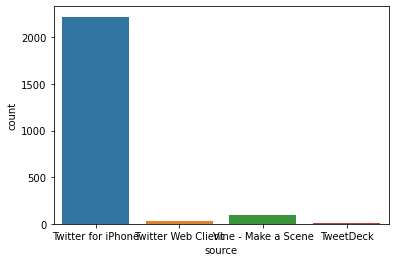

```python
sb.countplot(data = twitter_archive_copy, x = 'source');
```

### Issue #2: Dropping Tweets without images, i.e., expanded URLS

#### Define: In this section, the goal is using Python to drop Tweets without expanded URLs for uniformity in the dataframe

#### Code

```python
# Checking their scope using value_counts() method
twitter_archive_copy['expanded_urls'].value_counts().sum()
```

```
2297
```

```python
# Checking the total number of rows without expanded_urls
twitter_archive_copy['expanded_urls'].isnull().sum()
```

```
59
```

- As shown from above, only 59 rows have no expanded_urls
- This can be dropped for consistency

```python
twitter_archive_copy['expanded_urls'].dropna(inplace=True)
twitter_archive_copy.head()
```

|  | tweet_id | in_reply_to_status_id | in_reply_to_user_id | timestamp | source | text | retweeted_status_id | retweeted_status_user_id | retweeted_status_timestamp | expanded_urls | rating_numerator | rating_denominator | name | doggo | floofer | pupper | puppo |
| --- | --- | --- | --- | --- | --- | --- | --- | --- | --- | --- | --- | --- | --- | --- | --- | --- | --- |
| 0 | 892420643555336193 | NaN | NaN | 2017-08-01 16:23:56 +0000 | Twitter for iPhone | This is Phineas. He's a mystical boy. Only eve... | NaN | NaN | NaN | https://twitter.com/dog_rates/status/892420643... | 13 | 10 | Phineas | None | None | None | None |
| 1 | 892177421306343426 | NaN | NaN | 2017-08-01 00:17:27 +0000 | Twitter for iPhone | This is Tilly. She's just checking pup on you.... | NaN | NaN | NaN | https://twitter.com/dog_rates/status/892177421... | 13 | 10 | Tilly | None | None | None | None |
| 2 | 891815181378084864 | NaN | NaN | 2017-07-31 00:18:03 +0000 | Twitter for iPhone | This is Archie. He is a rare Norwegian Pouncin... | NaN | NaN | NaN | https://twitter.com/dog_rates/status/891815181... | 12 | 10 | Archie | None | None | None | None |
| 3 | 891689557279858688 | NaN | NaN | 2017-07-30 15:58:51 +0000 | Twitter for iPhone | This is Darla. She commenced a snooze mid meal... | NaN | NaN | NaN | https://twitter.com/dog_rates/status/891689557... | 13 | 10 | Darla | None | None | None | None |
| 4 | 891327558926688256 | NaN | NaN | 2017-07-29 16:00:24 +0000 | Twitter for iPhone | This is Franklin. He would like you to stop ca... | NaN | NaN | NaN | https://twitter.com/dog_rates/status/891327558... | 12 | 10 | Franklin | None | None | None | None |

```python
twitter_archive_copy = twitter_archive_copy[~twitter_archive_copy['expanded_urls'].isnull()]
```

#### Test

```python
# Checking if the expanded_urls, i.e., the 59 are in the new cleaned dataframe
# As shown in the table below, nothing is returned based on .isnull() method
twitter_archive_copy[twitter_archive_copy['expanded_urls'].isnull()]
```

|  | tweet_id | in_reply_to_status_id | in_reply_to_user_id | timestamp | source | text | retweeted_status_id | retweeted_status_user_id | retweeted_status_timestamp | expanded_urls | rating_numerator | rating_denominator | name | doggo | floofer | pupper | puppo |
| --- | --- | --- | --- | --- | --- | --- | --- | --- | --- | --- | --- | --- | --- | --- | --- | --- | --- |

```python
# If we check counts, it is now zero(0)
twitter_archive_copy['expanded_urls'].isnull().sum()
```

```
0
```

### Issue 3: Mix up in representing NaN values for some rows and others "None" "NaN"

### Define

- In the dataset, there are sections where NaN is used while others have None
- For consistency, all the NaN items in the dataframe can be replaced with "None"

#### Code

```python
twitter_archive_copy.replace(np.NaN, "None", inplace=True)
```

#### Test

```python
# Getting a sample of the data to see the changes
twitter_archive_copy.sample(3)
```

|  | tweet_id | in_reply_to_status_id | in_reply_to_user_id | timestamp | source | text | retweeted_status_id | retweeted_status_user_id | retweeted_status_timestamp | expanded_urls | rating_numerator | rating_denominator | name | doggo | floofer | pupper | puppo |
| --- | --- | --- | --- | --- | --- | --- | --- | --- | --- | --- | --- | --- | --- | --- | --- | --- | --- |
| 1923 | 674082852460433408 | None | None | 2015-12-08 04:27:30 +0000 | Twitter for iPhone | This is a Sagitariot Baklava mix. Loves her ne... | None | None | None | https://twitter.com/dog_rates/status/674082852... | 11 | 10 | a | None | None | None | None |
| 898 | 758854675097526272 | None | None | 2016-07-29 02:40:28 +0000 | Twitter for iPhone | This is Lilli Bee &amp; Honey Bear. Unfortunat... | None | None | None | https://twitter.com/dog_rates/status/758854675... | 11 | 10 | Lilli | None | None | None | None |
| 27 | 886736880519319552 | None | None | 2017-07-16 23:58:41 +0000 | Twitter for iPhone | This is Mingus. He's a wonderful father to his... | None | None | None | https://www.gofundme.com/mingusneedsus,https:/... | 13 | 10 | Mingus | None | None | None | None |

### Issue #4: Adjusting Rating in Numerator for Consistency in the Dataset

#### Code

```python
# Finding the number of ratings for all the data
twitter_archive_copy.info()
```

```
<class 'pandas.core.frame.DataFrame'>
Int64Index: 2297 entries, 0 to 2355
Data columns (total 17 columns):
 #   Column                      Non-Null Count  Dtype
---  ------                      --------------  -----
 0   tweet_id                    2297 non-null   int64
 1   in_reply_to_status_id       2297 non-null   object
 2   in_reply_to_user_id         2297 non-null   object
 3   timestamp                   2297 non-null   object
 4   source                      2297 non-null   object
 5   text                        2297 non-null   object
 6   retweeted_status_id         2297 non-null   object
 7   retweeted_status_user_id    2297 non-null   object
 8   retweeted_status_timestamp  2297 non-null   object
 9   expanded_urls               2297 non-null   object
 10  rating_numerator            2297 non-null   int64
 11  rating_denominator          2297 non-null   int64
 12  name                        2297 non-null   object
 13  doggo                       2297 non-null   object
 14  floofer                     2297 non-null   object
 15  pupper                      2297 non-null   object
 16  puppo                       2297 non-null   object
dtypes: int64(3), object(14)
memory usage: 323.0+ KB
```

#### Ratings for Numerator

```python
# Finding the number of ratings for all the data
twitter_archive_copy['rating_numerator'].value_counts()
```

```
12      547
11      455
10      455
13      339
9       156
8       102
7        53
14       50
5        35
6        32
3        19
4        16
2         9
1         6
0         2
```

[output cut: 21 more lines]

- As shown above, some ratings are 13, 12, 9, 8, 7, 6, and 5

```python
# Finding the number of ratings for numerator that are not 10 (!10)
twitter_archive_copy[twitter_archive_copy['rating_numerator'] != 10]
```

|  | tweet_id | in_reply_to_status_id | in_reply_to_user_id | timestamp | source | text | retweeted_status_id | retweeted_status_user_id | retweeted_status_timestamp | expanded_urls | rating_numerator | rating_denominator | name | doggo | floofer | pupper | puppo |
| --- | --- | --- | --- | --- | --- | --- | --- | --- | --- | --- | --- | --- | --- | --- | --- | --- | --- |
| 0 | 892420643555336193 | None | None | 2017-08-01 16:23:56 +0000 | Twitter for iPhone | This is Phineas. He's a mystical boy. Only eve... | None | None | None | https://twitter.com/dog_rates/status/892420643... | 13 | 10 | Phineas | None | None | None | None |
| 1 | 892177421306343426 | None | None | 2017-08-01 00:17:27 +0000 | Twitter for iPhone | This is Tilly. She's just checking pup on you.... | None | None | None | https://twitter.com/dog_rates/status/892177421... | 13 | 10 | Tilly | None | None | None | None |
| 2 | 891815181378084864 | None | None | 2017-07-31 00:18:03 +0000 | Twitter for iPhone | This is Archie. He is a rare Norwegian Pouncin... | None | None | None | https://twitter.com/dog_rates/status/891815181... | 12 | 10 | Archie | None | None | None | None |
| 3 | 891689557279858688 | None | None | 2017-07-30 15:58:51 +0000 | Twitter for iPhone | This is Darla. She commenced a snooze mid meal... | None | None | None | https://twitter.com/dog_rates/status/891689557... | 13 | 10 | Darla | None | None | None | None |
| 4 | 891327558926688256 | None | None | 2017-07-29 16:00:24 +0000 | Twitter for iPhone | This is Franklin. He would like you to stop ca... | None | None | None | https://twitter.com/dog_rates/status/891327558... | 12 | 10 | Franklin | None | None | None | None |
| ... | ... | ... | ... | ... | ... | ... | ... | ... | ... | ... | ... | ... | ... | ... | ... | ... | ... |
| 2351 | 666049248165822465 | None | None | 2015-11-16 00:24:50 +0000 | Twitter for iPhone | Here we have a 1949 1st generation vulpix. Enj... | None | None | None | https://twitter.com/dog_rates/status/666049248... | 5 | 10 | None | None | None | None | None |
| 2352 | 666044226329800704 | None | None | 2015-11-16 00:04:52 +0000 | Twitter for iPhone | This is a purebred Piers Morgan. Loves to Netf... | None | None | None | https://twitter.com/dog_rates/status/666044226... | 6 | 10 | a | None | None | None | None |
| 2353 | 666033412701032449 | None | None | 2015-11-15 23:21:54 +0000 | Twitter for iPhone | Here is a very happy pup. Big fan of well-main... | None | None | None | https://twitter.com/dog_rates/status/666033412... | 9 | 10 | a | None | None | None | None |
| 2354 | 666029285002620928 | None | None | 2015-11-15 23:05:30 +0000 | Twitter for iPhone | This is a western brown Mitsubishi terrier. Up... | None | None | None | https://twitter.com/dog_rates/status/666029285... | 7 | 10 | a | None | None | None | None |
| 2355 | 666020888022790149 | None | None | 2015-11-15 22:32:08 +0000 | Twitter for iPhone | Here we have a Japanese Irish Setter. Lost eye... | None | None | None | https://twitter.com/dog_rates/status/666020888... | 8 | 10 | None | None | None | None | None |

1842 rows × 17 columns

- The code above shows that 1842 rows have a rating that is not 10 (!10)

```python
# Identifying and recording the indexes of all rating numerator not equal to 10 using the query method
none_10_rating_numerator = twitter_archive_copy.query("rating_numerator != 10")['rating_numerator'].index
```

```python
# Changing the rating numerators from other values to 10
for index in none_10_rating_numerator:
    twitter_archive_copy.at[index,'rating_numerator'] = 10
```

#### Test

```python
# Using the previous method, to now check the proportion of rows with none-10 as the numerator
twitter_archive_copy[twitter_archive_copy['rating_numerator'] != 10]
```

|  | tweet_id | in_reply_to_status_id | in_reply_to_user_id | timestamp | source | text | retweeted_status_id | retweeted_status_user_id | retweeted_status_timestamp | expanded_urls | rating_numerator | rating_denominator | name | doggo | floofer | pupper | puppo |
| --- | --- | --- | --- | --- | --- | --- | --- | --- | --- | --- | --- | --- | --- | --- | --- | --- | --- |

- As shown above, the result brings an empty dataframe where columns now have no values
- We can recheck the result by using the value_counts() method to know how many of the rows have 10 as the rating
- The response should show all the rows in the dataframe, i.e., 2297, which means now all rows have a 10 as the rating

```python
# Finding the number of counts for each of the ratings in the dataframe
twitter_archive_copy['rating_numerator'].value_counts()
```

```
10    2297
Name: rating_numerator, dtype: int64
```

#### Test

```python
# Using the previous method, to now check the proportion of rows with none-10 as the numerator
twitter_archive_copy[twitter_archive_copy['rating_numerator'] != 10]
```

|  | tweet_id | in_reply_to_status_id | in_reply_to_user_id | timestamp | source | text | retweeted_status_id | retweeted_status_user_id | retweeted_status_timestamp | expanded_urls | rating_numerator | rating_denominator | name | doggo | floofer | pupper | puppo |
| --- | --- | --- | --- | --- | --- | --- | --- | --- | --- | --- | --- | --- | --- | --- | --- | --- | --- |

### Issue # 5: Removing Underscores for names in image descriptions

#### Define:

- As part of the identified issues, some names have underscores likely confusing
- For example, "Rhodesian_ridgeback" for "Rhodesian ridgeback" hence a need to remove these for consistency

#### Code

```python
# Overview of the dataset
image_predictions_copy.sample(5)
```

|  | tweet_id | jpg_url | img_num | p1 | p1_conf | p1_dog | p2 | p2_conf | p2_dog | p3 | p3_conf | p3_dog |
| --- | --- | --- | --- | --- | --- | --- | --- | --- | --- | --- | --- | --- |
| 1925 | 857393404942143489 | https://pbs.twimg.com/media/C-YSwA_XgAEOr25.jpg | 3 | malamute | 0.841597 | True | Siberian_husky | 0.073644 | True | Eskimo_dog | 0.072129 | True |
| 879 | 698549713696649216 | https://pbs.twimg.com/media/CbG_QRJXEAALVWy.jpg | 1 | French_bulldog | 0.998544 | True | Boston_bull | 0.001404 | True | boxer | 0.000023 | True |
| 1230 | 745712589599014916 | https://pbs.twimg.com/media/CllNnkWWMAEDIAR.jpg | 1 | seat_belt | 0.379055 | False | chow | 0.062754 | True | minibus | 0.052423 | False |
| 2065 | 890240255349198849 | https://pbs.twimg.com/media/DFrEyVuW0AAO3t9.jpg | 1 | Pembroke | 0.511319 | True | Cardigan | 0.451038 | True | Chihuahua | 0.029248 | True |
| 245 | 670468609693655041 | https://pbs.twimg.com/media/CU37pEoWUAAitje.jpg | 1 | minivan | 0.730152 | False | beach_wagon | 0.078661 | False | car_wheel | 0.064346 | False |

```python
# Replacing Underscores in the dataset
p1_names = image_predictions_copy['p1'].values
p2_names = image_predictions_copy['p2'].values
p3_names = image_predictions_copy['p3'].values
for x in p1_names:
    image_predictions_copy['p1'] = image_predictions_copy['p1'].str.replace("_", " ")
```

```python
for x in p2_names:
    image_predictions_copy['p2'] = image_predictions_copy['p2'].str.replace("_", " ")
```

```python
for x in p3_names:
    image_predictions_copy['p3'] = image_predictions_copy['p3'].str.replace("_", " ")
```

#### Test

```python
# Using assert
assert '_' not in image_predictions_copy
```

> Asserrt gives no response for the above

```python
# Sampling the data
image_predictions_copy.sample(5)
```

|  | tweet_id | jpg_url | img_num | p1 | p1_conf | p1_dog | p2 | p2_conf | p2_dog | p3 | p3_conf | p3_dog |
| --- | --- | --- | --- | --- | --- | --- | --- | --- | --- | --- | --- | --- |
| 1195 | 740365076218183684 | https://pbs.twimg.com/media/CkZOGhJWsAAHvPv.jpg | 1 | bow tie | 0.246313 | False | Windsor tie | 0.172446 | False | mushroom | 0.137516 | False |
| 1393 | 767191397493538821 | https://pbs.twimg.com/media/CqWcgcqWcAI43jm.jpg | 1 | patio | 0.708665 | False | boathouse | 0.110056 | False | pier | 0.039532 | False |
| 1097 | 720340705894408192 | https://pbs.twimg.com/media/Cf8qDFbWwAEf8M3.jpg | 1 | alp | 0.320126 | False | lawn mower | 0.080808 | False | viaduct | 0.065321 | False |
| 541 | 677187300187611136 | https://pbs.twimg.com/media/CWXaQMBWcAAATDi.jpg | 1 | English setter | 0.282396 | True | Shih-Tzu | 0.084112 | True | Old English sheepdog | 0.059538 | True |
| 1845 | 838921590096166913 | https://pbs.twimg.com/media/C6Ryuf7UoAAFX4a.jpg | 1 | Border terrier | 0.664538 | True | Brabancon griffon | 0.170451 | True | Yorkshire terrier | 0.087824 | True |

### Issue # 6: Time stamp challenges, in that it is represented both as date and clock times on same column

#### Define

- This section focuses on aligning the timestamp column, so that there is consistency in the recorded timeline
- Changing the timestamp column to be represented as datetime for consistency

#### Code

```python
# Checking the timestamp column for processing
twitter_archive_copy['timestamp']
```

```
0       2017-08-01 16:23:56 +0000
1       2017-08-01 00:17:27 +0000
2       2017-07-31 00:18:03 +0000
3       2017-07-30 15:58:51 +0000
4       2017-07-29 16:00:24 +0000
                  ...
2351    2015-11-16 00:24:50 +0000
2352    2015-11-16 00:04:52 +0000
2353    2015-11-15 23:21:54 +0000
2354    2015-11-15 23:05:30 +0000
2355    2015-11-15 22:32:08 +0000
Name: timestamp, Length: 2297, dtype: object
```

```python
# As shown above, timestamp is of object datatype, and we can change it to datetime
# Converting the current timestamp column to effectively have a datetime format for better quality
# Here, we use the pandas to_datetime() method

twitter_archive_copy['timestamp'] = pd.to_datetime(twitter_archive_copy['timestamp'])
```

### Test

```python
# Getting an overview of the whole dataframe, to see the new timestamp column with new datatime format
# A random sample of 10 is chosen for overview
twitter_archive_copy['timestamp'].sample(5)
```

```
2156   2015-11-25 19:25:57+00:00
283    2017-03-07 03:22:35+00:00
1121   2016-05-13 00:56:32+00:00
552    2016-12-01 19:56:00+00:00
495    2016-12-26 00:00:03+00:00
Name: timestamp, dtype: datetime64[ns, UTC]
```

### Issue 7: Name inconsistencies across the dog name column in twitter_archive dataset

### Define

- In the name column, there are some irrelevant or non-clear names for the dogs, e.g., "a", "an" and "the", etc.
- As a means in improving the dataframe's quality, adjusting this information is useful for subsequent analysis

#### Code

```python
# Checking the name column and listing some of its contents for better assessment
# The below list shows some names, and others which are hard to understand
twitter_archive_copy['name']
```

```
0        Phineas
1          Tilly
2         Archie
3          Darla
4       Franklin
          ...
2351        None
2352           a
2353           a
2354           a
2355        None
Name: name, Length: 2297, dtype: object
```

```python
# Using for loop, we can list the dog names, and check those that are suspicious as shown below
for x in twitter_archive_copy['name']:
    print(x)
```

[output not shown]

[output cut: 2242 more lines]

[output not shown]

- From above, we can document a list of names which look suspecious or not informative
- Based on personal judgment as a data analyst by looking at the sample, the below names are not clear
- From the dataset, it is noticeable that most of the suspicious names were in lower-case, except "None"
- Hence, listing all lowercase names can help identify the poor names for the dogs

```python
twitter_archive_copy[twitter_archive_copy.name.str.islower()].name.value_counts()
```

```
a               55
the              8
an               7
very             5
just             4
quite            4
one              4
getting          2
actually         2
mad              2
not              2
old              1
life             1
officially       1
light            1
by               1
infuriating      1
such             1
all              1
unacceptable     1
this             1
his              1
my               1
incredibly       1
space            1
Name: name, dtype: int64
```

```python
# Saving the above in a list
unclear_name_list = twitter_archive_copy[twitter_archive_copy.name.str.islower()].name.values
```

```python
unclear_name_list
```

```
array(['such', 'a', 'quite', 'quite', 'quite', 'not', 'one', 'incredibly',
       'a', 'mad', 'an', 'very', 'a', 'very', 'just', 'my', 'one', 'not',
       'his', 'one', 'a', 'a', 'a', 'an', 'very', 'actually', 'a', 'just',
       'getting', 'mad', 'very', 'this', 'unacceptable', 'all', 'a',
       'old', 'a', 'infuriating', 'a', 'a', 'a', 'an', 'a', 'a', 'very',
       'getting', 'just', 'a', 'the', 'the', 'actually', 'by', 'a',
       'officially', 'a', 'the', 'the', 'a', 'a', 'a', 'a', 'life', 'a',
       'one', 'a', 'a', 'a', 'light', 'just', 'space', 'a', 'the', 'a',
       'a', 'a', 'a', 'a', 'a', 'a', 'a', 'a', 'an', 'a', 'the', 'a', 'a',
       'a', 'a', 'a', 'a', 'a', 'a', 'a', 'a', 'a', 'quite', 'a', 'an',
       'a', 'an', 'the', 'the', 'a', 'a', 'an', 'a', 'a', 'a', 'a'],
      dtype=object)
```

```python
# Adding NaN to the end of the list
unclear_name_list = np.append(unclear_name_list, np.NaN)
unclear_name_list
```

```
array(['such', 'a', 'quite', 'quite', 'quite', 'not', 'one', 'incredibly',
       'a', 'mad', 'an', 'very', 'a', 'very', 'just', 'my', 'one', 'not',
       'his', 'one', 'a', 'a', 'a', 'an', 'very', 'actually', 'a', 'just',
       'getting', 'mad', 'very', 'this', 'unacceptable', 'all', 'a',
       'old', 'a', 'infuriating', 'a', 'a', 'a', 'an', 'a', 'a', 'very',
       'getting', 'just', 'a', 'the', 'the', 'actually', 'by', 'a',
       'officially', 'a', 'the', 'the', 'a', 'a', 'a', 'a', 'life', 'a',
       'one', 'a', 'a', 'a', 'light', 'just', 'space', 'a', 'the', 'a',
       'a', 'a', 'a', 'a', 'a', 'a', 'a', 'a', 'an', 'a', 'the', 'a', 'a',
       'a', 'a', 'a', 'a', 'a', 'a', 'a', 'a', 'a', 'quite', 'a', 'an',
       'a', 'an', 'the', 'the', 'a', 'a', 'an', 'a', 'a', 'a', 'a', nan],
      dtype=object)
```

```python
# Adding "None" to the end of the list
unclear_name_list = np.append(unclear_name_list, "None")
unclear_name_list
```

```
array(['such', 'a', 'quite', 'quite', 'quite', 'not', 'one', 'incredibly',
       'a', 'mad', 'an', 'very', 'a', 'very', 'just', 'my', 'one', 'not',
       'his', 'one', 'a', 'a', 'a', 'an', 'very', 'actually', 'a', 'just',
       'getting', 'mad', 'very', 'this', 'unacceptable', 'all', 'a',
       'old', 'a', 'infuriating', 'a', 'a', 'a', 'an', 'a', 'a', 'very',
       'getting', 'just', 'a', 'the', 'the', 'actually', 'by', 'a',
       'officially', 'a', 'the', 'the', 'a', 'a', 'a', 'a', 'life', 'a',
       'one', 'a', 'a', 'a', 'light', 'just', 'space', 'a', 'the', 'a',
       'a', 'a', 'a', 'a', 'a', 'a', 'a', 'a', 'an', 'a', 'the', 'a', 'a',
       'a', 'a', 'a', 'a', 'a', 'a', 'a', 'a', 'a', 'quite', 'a', 'an',
       'a', 'an', 'the', 'the', 'a', 'a', 'an', 'a', 'a', 'a', 'a', nan,
       'None'], dtype=object)
```

```python
# Next, for any of the listed names above, the best option can be replacing the names with a common understandable name
# In this case, all unclear names will be replaced with "Unspecified Dog"
# The code below can be used to replace the 14 unclear names with "Unspecified Dog" using replace
# Using for loop, and the list of unclear names, we can replace in the name column as below with "Unspecified Dog"
for x in unclear_name_list:
    twitter_archive_copy['name'].replace(x, 'Dog Unknown', inplace = True)
```

- The Python code above iterates through the name column, replacing all names in the unclear list

#### Test

```python
# Using value counts to get an overview of each dog's name
twitter_archive_copy['name'].value_counts()
```

```
Dog Unknown    795
Charlie         12
Lucy            11
Cooper          11
Oliver          11
              ...
Devón            1
Gert             1
Dex              1
Ace              1
Christoper       1
Name: name, Length: 932, dtype: int64
```

```python
# Running code to check the list of names in the dataframe
twitter_archive_copy['name'].sample(10)
```

```
834           Chevy
1574    Dog Unknown
627           Rizzy
605     Dog Unknown
951            Lola
1133       Flurpson
1319    Dog Unknown
1729    Dog Unknown
2141           Zoey
1428    Dog Unknown
Name: name, dtype: object
```

- As shown from above, none of the listed suspicious names can be seen in the new dataframe

### Issue 8 Inconsistencies in image_predictions names with uppper and lowercases

#### Define

- For consistency, writing the predictions with proper case is needed for quality
- For example, in the p1, p2, and p3 columns, there are inconsistencies
- Examples includes beagle => Beagle, malamute => Malamute, chow ==> Chow
- Also, some names which underscores were removed as part of Issue # 5 can also be written in Capital Case

#### Code

```python
# Rewriting the p1, p2, and p3 columns dog names into capital for each word
# First, saving the p1, p2 and p3 values in a list

p1_names = image_predictions_copy['p1'].values
p2_names = image_predictions_copy['p2'].values
p3_names = image_predictions_copy['p3'].values
# p1
# using for loop to change to upper case using title() method
for name in p1_names:
    if name.islower():
        image_predictions_copy['p1'] = image_predictions_copy['p1'].str.title()
```

```python
# p2
for name in p2_names:
    if name.islower():
        image_predictions_copy['p2']= image_predictions_copy['p2'].str.title()
```

```python
# p3
for name in p3_names:
    if name.islower():
        image_predictions_copy['p3']= image_predictions_copy['p3'].str.title()
```

#### Test

```python
# Checking the new data frame
image_predictions_copy.p1
```

```
0       Welsh Springer Spaniel
1                      Redbone
2              German Shepherd
3          Rhodesian Ridgeback
4           Miniature Pinscher
                 ...
2070                    Basset
2071               Paper Towel
2072                 Chihuahua
2073                 Chihuahua
2074                    Orange
Name: p1, Length: 2075, dtype: object
```

```python
image_predictions_copy.p2
```

```
0                   Collie
1       Miniature Pinscher
2                 Malinois
3                  Redbone
4               Rottweiler
               ...
2070      English Springer
2071    Labrador Retriever
2072              Malamute
2073              Pekinese
2074                 Bagel
Name: p2, Length: 2075, dtype: object
```

```python
image_predictions_copy.p3
```

```
0                 Shetland Sheepdog
1               Rhodesian Ridgeback
2                        Bloodhound
3                Miniature Pinscher
4                          Doberman
                   ...
2070    German Short-Haired Pointer
2071                        Spatula
2072                         Kelpie
2073                       Papillon
2074                         Banana
Name: p3, Length: 2075, dtype: object
```

## Tidiness Issues

```python
# Saving data to manipulate
twitter_cleaned = twitter_archive_copy.copy()
```

### Issue 1: Agglomerating dog tyoes of "doggo", "floofer", "pupper" & "puppo" into a single column

#### Define

- In the archive dataset, the "doggo", "floofer", "pupper" & "puppo" can be merged into a single column for better presentation

#### Code

```python
twitter_cleaned.head()
```

|  | tweet_id | in_reply_to_status_id | in_reply_to_user_id | timestamp | source | text | retweeted_status_id | retweeted_status_user_id | retweeted_status_timestamp | expanded_urls | rating_numerator | rating_denominator | name | doggo | floofer | pupper | puppo |
| --- | --- | --- | --- | --- | --- | --- | --- | --- | --- | --- | --- | --- | --- | --- | --- | --- | --- |
| 0 | 892420643555336193 | None | None | 2017-08-01 16:23:56+00:00 | Twitter for iPhone | This is Phineas. He's a mystical boy. Only eve... | None | None | None | https://twitter.com/dog_rates/status/892420643... | 10 | 10 | Phineas | None | None | None | None |
| 1 | 892177421306343426 | None | None | 2017-08-01 00:17:27+00:00 | Twitter for iPhone | This is Tilly. She's just checking pup on you.... | None | None | None | https://twitter.com/dog_rates/status/892177421... | 10 | 10 | Tilly | None | None | None | None |
| 2 | 891815181378084864 | None | None | 2017-07-31 00:18:03+00:00 | Twitter for iPhone | This is Archie. He is a rare Norwegian Pouncin... | None | None | None | https://twitter.com/dog_rates/status/891815181... | 10 | 10 | Archie | None | None | None | None |
| 3 | 891689557279858688 | None | None | 2017-07-30 15:58:51+00:00 | Twitter for iPhone | This is Darla. She commenced a snooze mid meal... | None | None | None | https://twitter.com/dog_rates/status/891689557... | 10 | 10 | Darla | None | None | None | None |
| 4 | 891327558926688256 | None | None | 2017-07-29 16:00:24+00:00 | Twitter for iPhone | This is Franklin. He would like you to stop ca... | None | None | None | https://twitter.com/dog_rates/status/891327558... | 10 | 10 | Franklin | None | None | None | None |

```python
# Taking all the "doggo", "floofer", "pupper" & "puppo" and storing them into one column called "dog_phase" aspect
```

```python
# Making a copy of the cleaned twitter archive dataset
twitter_archive_combined = twitter_cleaned.copy()
```

```python
twitter_archive_combined['dog_types'] = twitter_archive_combined[['pupper','doggo', 'floofer', 'puppo']].apply(lambda x: ', '.join(x), axis=1)
```

```python
# Overview of joined dataset
twitter_archive_combined
```

|  | tweet_id | in_reply_to_status_id | in_reply_to_user_id | timestamp | source | text | retweeted_status_id | retweeted_status_user_id | retweeted_status_timestamp | expanded_urls | rating_numerator | rating_denominator | name | doggo | floofer | pupper | puppo | dog_types |
| --- | --- | --- | --- | --- | --- | --- | --- | --- | --- | --- | --- | --- | --- | --- | --- | --- | --- | --- |
| 0 | 892420643555336193 | None | None | 2017-08-01 16:23:56+00:00 | Twitter for iPhone | This is Phineas. He's a mystical boy. Only eve... | None | None | None | https://twitter.com/dog_rates/status/892420643... | 10 | 10 | Phineas | None | None | None | None | None, None, None, None |
| 1 | 892177421306343426 | None | None | 2017-08-01 00:17:27+00:00 | Twitter for iPhone | This is Tilly. She's just checking pup on you.... | None | None | None | https://twitter.com/dog_rates/status/892177421... | 10 | 10 | Tilly | None | None | None | None | None, None, None, None |
| 2 | 891815181378084864 | None | None | 2017-07-31 00:18:03+00:00 | Twitter for iPhone | This is Archie. He is a rare Norwegian Pouncin... | None | None | None | https://twitter.com/dog_rates/status/891815181... | 10 | 10 | Archie | None | None | None | None | None, None, None, None |
| 3 | 891689557279858688 | None | None | 2017-07-30 15:58:51+00:00 | Twitter for iPhone | This is Darla. She commenced a snooze mid meal... | None | None | None | https://twitter.com/dog_rates/status/891689557... | 10 | 10 | Darla | None | None | None | None | None, None, None, None |
| 4 | 891327558926688256 | None | None | 2017-07-29 16:00:24+00:00 | Twitter for iPhone | This is Franklin. He would like you to stop ca... | None | None | None | https://twitter.com/dog_rates/status/891327558... | 10 | 10 | Franklin | None | None | None | None | None, None, None, None |
| ... | ... | ... | ... | ... | ... | ... | ... | ... | ... | ... | ... | ... | ... | ... | ... | ... | ... | ... |
| 2351 | 666049248165822465 | None | None | 2015-11-16 00:24:50+00:00 | Twitter for iPhone | Here we have a 1949 1st generation vulpix. Enj... | None | None | None | https://twitter.com/dog_rates/status/666049248... | 10 | 10 | Dog Unknown | None | None | None | None | None, None, None, None |
| 2352 | 666044226329800704 | None | None | 2015-11-16 00:04:52+00:00 | Twitter for iPhone | This is a purebred Piers Morgan. Loves to Netf... | None | None | None | https://twitter.com/dog_rates/status/666044226... | 10 | 10 | Dog Unknown | None | None | None | None | None, None, None, None |
| 2353 | 666033412701032449 | None | None | 2015-11-15 23:21:54+00:00 | Twitter for iPhone | Here is a very happy pup. Big fan of well-main... | None | None | None | https://twitter.com/dog_rates/status/666033412... | 10 | 10 | Dog Unknown | None | None | None | None | None, None, None, None |
| 2354 | 666029285002620928 | None | None | 2015-11-15 23:05:30+00:00 | Twitter for iPhone | This is a western brown Mitsubishi terrier. Up... | None | None | None | https://twitter.com/dog_rates/status/666029285... | 10 | 10 | Dog Unknown | None | None | None | None | None, None, None, None |
| 2355 | 666020888022790149 | None | None | 2015-11-15 22:32:08+00:00 | Twitter for iPhone | Here we have a Japanese Irish Setter. Lost eye... | None | None | None | https://twitter.com/dog_rates/status/666020888... | 10 | 10 | Dog Unknown | None | None | None | None | None, None, None, None |

2297 rows × 18 columns

```python
# Dropping the doggo floofer, pupper, puppo columns
```

```python
drop_columns = ['doggo' ,'floofer', 'pupper', 'puppo']
twitter_archive_combined.drop(columns= drop_columns, inplace=True)
```

```python
# Removing all None in the dog_types
twitter_archive_combined = twitter_archive_combined.replace(regex=r'(None,? ?)', value='').replace(regex=r'(, $)', value='')
```

```python
# Replacing empty occurences with NaN
twitter_archive_combined = twitter_archive_combined.replace(regex=r'', value= np.nan)
```

### Test

```python
# Counting the proportion of dog types using .value_counts() method
twitter_archive_combined['dog_types'].value_counts()
```

```
pupper            243
doggo              80
puppo              28
pupper, doggo      12
floofer             9
doggo, puppo        1
doggo, floofer      1
Name: dog_types, dtype: int64
```

### Issue 2: Merging of Data into a Single Table for Tidiness

```python
# In image predictions and twitter archive data, the tweet+ids are same, and hence the data can be merged
```

```python
image_predictions_copy['tweet_id']
```

```
0       666020888022790149
1       666029285002620928
2       666033412701032449
3       666044226329800704
4       666049248165822465
               ...
2070    891327558926688256
2071    891689557279858688
2072    891815181378084864
2073    892177421306343426
2074    892420643555336193
Name: tweet_id, Length: 2075, dtype: int64
```

```python
twitter_archive_combined['tweet_id']
```

```
0       892420643555336193
1       892177421306343426
2       891815181378084864
3       891689557279858688
4       891327558926688256
               ...
2351    666049248165822465
2352    666044226329800704
2353    666033412701032449
2354    666029285002620928
2355    666020888022790149
Name: tweet_id, Length: 2297, dtype: int64
```

```python
# First, merging tweet_json_copy and image_predictions_copy since inner takes two dataframes
new_clean_df = pd.merge(tweet_json_copy, image_predictions_copy,
                            on='tweet_id', how='inner')
```

```python
# Next, mergin the above with twitter_archive_combined
final_merged_df = pd.merge(new_clean_df, twitter_archive_combined,
                            on='tweet_id', how='inner')
```

```python
final_merged_df.sample(3)
```

|  | tweet_id | retweet_count | favorite_count | is_quote_status | jpg_url | img_num | p1 | p1_conf | p1_dog | p2 | ... | source | text | retweeted_status_id | retweeted_status_user_id | retweeted_status_timestamp | expanded_urls | rating_numerator | rating_denominator | name | dog_types |
| --- | --- | --- | --- | --- | --- | --- | --- | --- | --- | --- | --- | --- | --- | --- | --- | --- | --- | --- | --- | --- | --- |
| 2294 | 780601303617732608 | 3117 | 11399 | False | https://pbs.twimg.com/media/CtVAvX-WIAAcGTf.jpg | 1 | Saint Bernard | 0.995143 | True | Cardigan | ... | Twitter for iPhone | Meet Hercules. He can have whatever he wants f... | NaN | NaN | NaN | https://twitter.com/dog_rates/status/780601303... | 10 | 10 | Hercules | NaN |
| 4995 | 671166507850801152 | 390 | 931 | False | https://pbs.twimg.com/media/CVB2TnWUYAA2pAU.jpg | 1 | Refrigerator | 0.829772 | False | Toilet Seat | ... | Twitter for iPhone | This is Herm. It's his first day of potty trai... | NaN | NaN | NaN | https://twitter.com/dog_rates/status/671166507... | 10 | 10 | Herm | NaN |
| 4888 | 672267570918129665 | 533 | 1313 | False | https://pbs.twimg.com/media/CVRfyZxWUAAFIQR.jpg | 1 | Irish Terrier | 0.716932 | True | Miniature Pinscher | ... | Twitter for iPhone | When you accidentally open up the front facing... | NaN | NaN | NaN | https://twitter.com/dog_rates/status/672267570... | 10 | 10 | Dog Unknown | NaN |

3 rows × 28 columns

```python
# Checking columns
final_merged_df.columns
```

```
Index(['tweet_id', 'retweet_count', 'favorite_count', 'is_quote_status',
       'jpg_url', 'img_num', 'p1', 'p1_conf', 'p1_dog', 'p2', 'p2_conf',
       'p2_dog', 'p3', 'p3_conf', 'p3_dog', 'in_reply_to_status_id',
       'in_reply_to_user_id', 'timestamp', 'source', 'text',
       'retweeted_status_id', 'retweeted_status_user_id',
       'retweeted_status_timestamp', 'expanded_urls', 'rating_numerator',
       'rating_denominator', 'name', 'dog_types'],
      dtype='object')
```

## Storing Data

Save gathered, assessed, and cleaned master dataset to a CSV file named "twitter_archive_master.csv".

```python
# Storing to master with name "twitter_archive_master.csv"
final_merged_df.to_csv('twitter_archive_master.csv', index=False)
```